# Homework 7

Xiaoqing Ye

Question 1 (1) y=infestation rate (aphids/100 leaves); x1 = mean temperature (°C); x2 = mean relative humidity Comment: From the matrix plot, there is a negative linear trend between infestation rate and mean temperature, where higher the mean temperature, lower the infestation rate; There is a positive trend between infestation rate and mean relative humidity, where higher the mean relative humidity, higher the infestation rate; For predictior variables, there is a negative trend between mean temperature and mean relative humidity, where higher the mean temperature, lower the mean relative humidity.

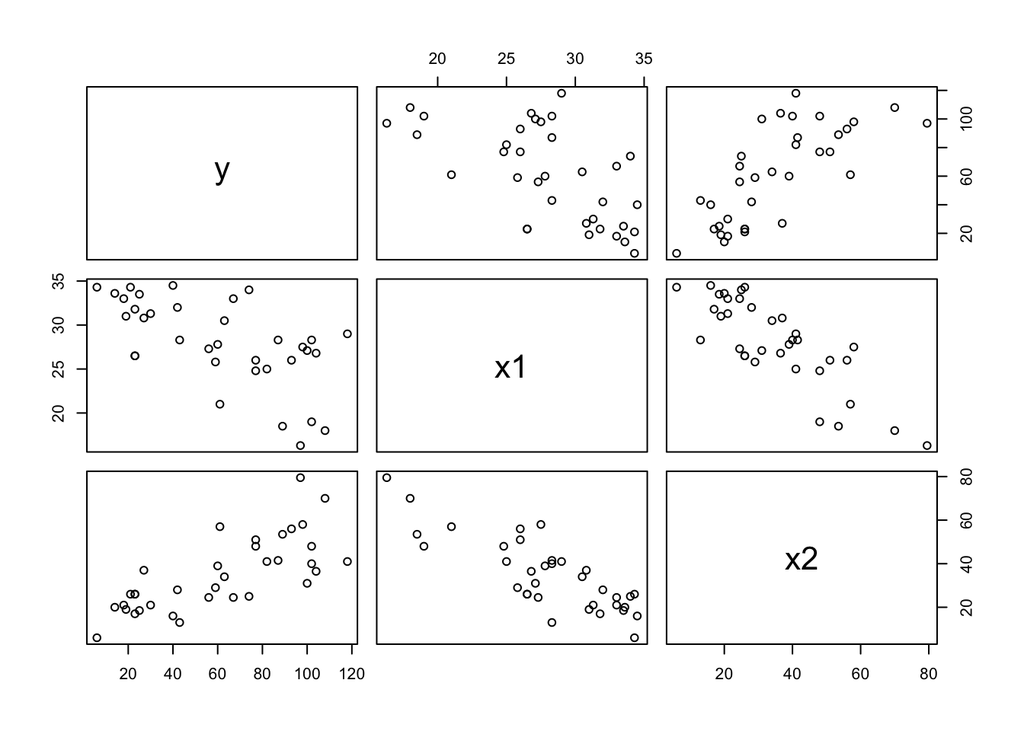

```r
aphideData=read.csv("aphideData.csv", header=T)
plot(aphideData)
```

2. Comment: From the correlation plot, the corrolation bewteen infestation rate and mean temperature is -0.62, where higher the mean temperature, lower the infestation rate; The corrolation bewteen infestation rate and mean relative humidity is 0.74, where higher the mean relative humidity, higher the infestation rate; The corrolation bewteen mean temperature and mean relative humidity is -0.82, where higher the mean temperature, lower the mean relative humidity.

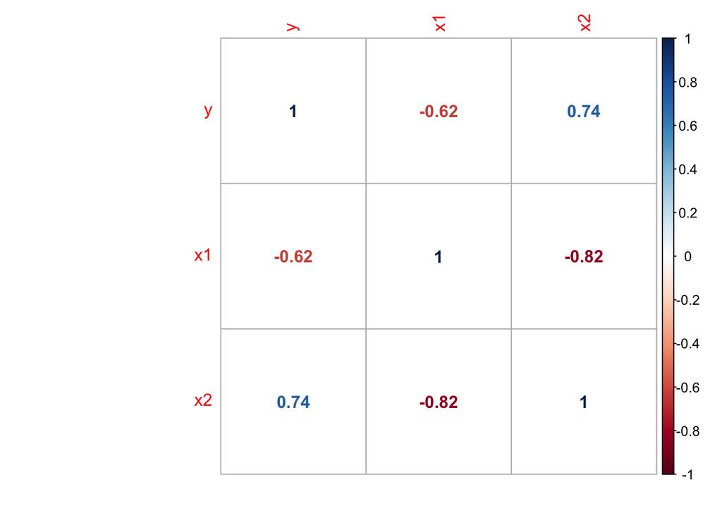

```r
library(corrplot)
aphideCorMat=cor(aphideData)
corrplot(aphideCorMat, method="number")
```

3. Comment: Linearity and Constant Variance: Since all the points in the residual plots: Studentized residual Vs. Fitted and Studentized residual Vs. each predictor variable are within (-3, 3) limits randomly scattered around zero horizontal line without any particular pattern, we don’t have any concerns of possible violations of linearity. They do not suggest any departure from homogeneity either. Breush-Pagan test also support the homogeneity of the errors (p value=0.8299>0.05).

Normality: Points in the normal QQ plot stay close to the reference line supporting the normality of the errors. This can be further confirmed by looking at the p value for the Anderson-Darling test (p value 0.5832>0.05)

Independence: For this data, it would reasonable for us to assume errors are independent as the researcher is randomly selecting aphids.

Multicollinearity: All the vif values are bigger than 1 but smaller than 5, indicating some correlations among the predictor variables.

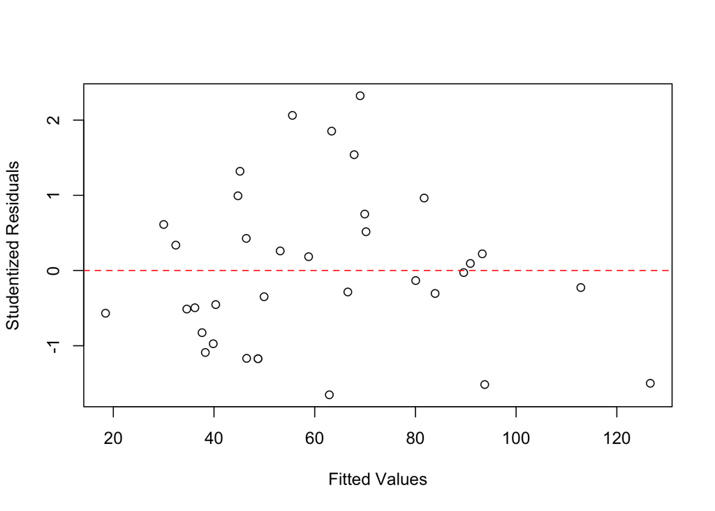

```r
model1=lm(y~x1+x2, data=aphideData)
library(MASS)
stud.residuals=studres(model1)
fitted.values= fitted.values(model1)
plot(x=fitted.values, y=stud.residuals, xlab="Fitted Values", ylab="Studentized Residuals")
abline(h=0, col="red", lty=2)
abline(h=-3, col="blue", lty=3)
abline(h=3, col="blue", lty=3)
```

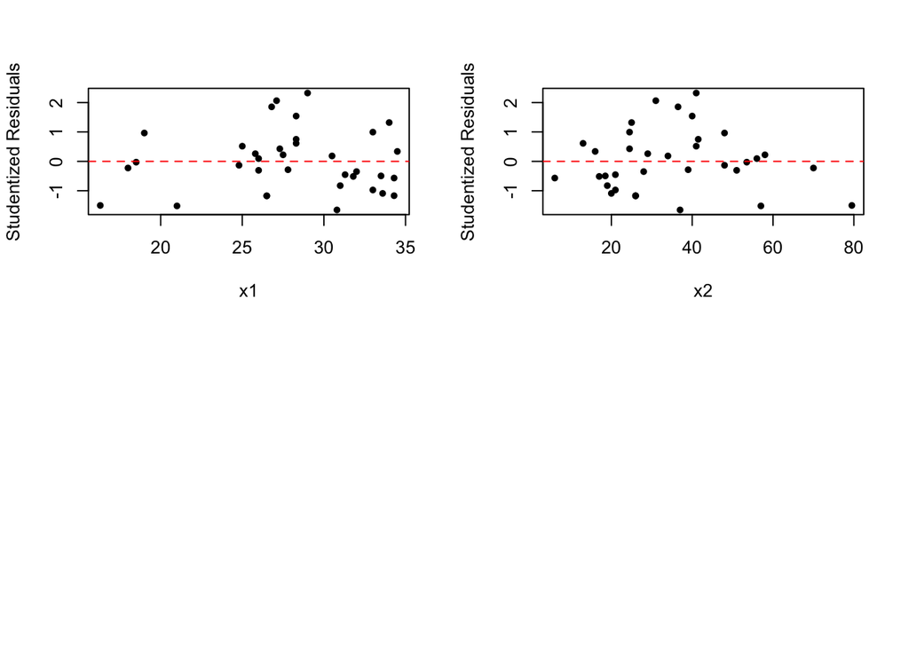

```r
par(mfrow=c(2,2)) #This line split the plot window in to 2 by 2 small windows
plot(x = aphideData$x1, y = stud.residuals, xlab = "x1", ylab = "Studentized Residuals", pch=20)
abline(h=0, col="red",lty=2)
abline(h=-3,col="blue",lty=3)
abline(h=3,col="blue",lty=3)

plot(x = aphideData$x2, y = stud.residuals, xlab = "x2", ylab = "Studentized Residuals", pch=20)
abline(h=0, col="red",lty=2)
abline(h=-3,col="blue",lty=3)
abline(h=3,col="blue",lty=3)
```

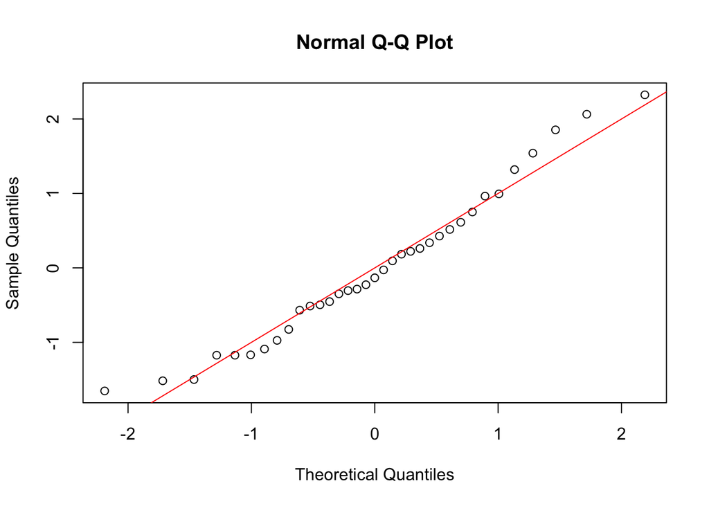

```r
par(mfrow=c(1,1))
qqnorm(stud.residuals)
abline(a=0, b=1, col="red")
```

```r
library(nortest)
ad.test(stud.residuals)
```

```
##
##  Anderson-Darling normality test
##
## data:  stud.residuals
## A = 0.29295, p-value = 0.5832
```

```r
 #Breush-Pagan test
library(lmtest)
bptest(model1)
```

```
##
##  studentized Breusch-Pagan test
##
## data:  model1
## BP = 0.37287, df = 2, p-value = 0.8299
```

```r
library(car)
vif(model1)
```

```
##       x1       x2
## 3.076691 3.076691
```

Comment: Outliers: From the plot of fitted and observed values, we can see they agree with each other most the time.

Influential: Although, there seems to be at least one observation with high-leverage value, none of the observations seems to be influential

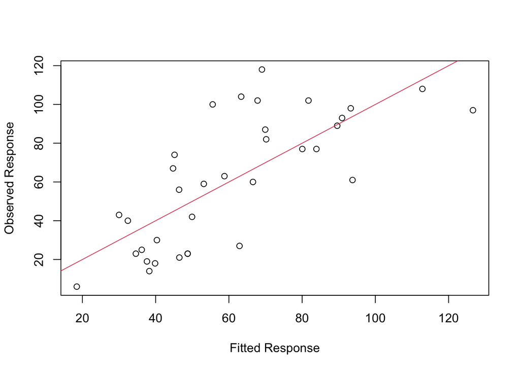

```r
#Plot of fitted and observed values
plot(fitted.values,aphideData$y, xlab="Fitted Response", ylab="Observed Response")
abline(a=0,b=1,col=2)
```